# pigpen_041518

Zhenghan Qi

4/18/2018

## Cronbach’s alpha for the sentence task

- Action - list Related-1Ref: 0.93, Related-2Ref: 0.88, Unrelated-1Ref: 0.89, Unrelated-2Ref: 0.84, Average: 0.89
- DD2 Look - list Related-1Ref: 0.72, Related-2Ref: 0.77, Unrelated-1Ref: 0.82, Unrelated-2Ref: 0.70, Average: 0.75

## Cronbach’s alpha for the Flanker task block 3

- 0.88

## Pigpen Action Analysis

- testing main experimental effects on action
  - significant effect of ambiguity, marginal effect of referential context, and marginal interaction between ambiguity and referential context

```r
pigpen.lmer<- lmer(elog ~ ambcode*refcode  + (1 | Subnum) + (0+ambcode|Subnum), control = lmerControl(optimizer = "optimx", calc.derivs = FALSE, optCtrl = list(method = "nlminb", starttests = FALSE, kkt = FALSE)), data=submean)
summary(pigpen.lmer)
```

```
## Linear mixed model fit by REML. t-tests use Satterthwaite's method [
## lmerModLmerTest]
## Formula: elog ~ ambcode * refcode + (1 | Subnum) + (0 + ambcode | Subnum)
##    Data: submean
## Control:
## lmerControl(optimizer = "optimx", calc.derivs = FALSE, optCtrl = list(method = "nlminb",
##     starttests = FALSE, kkt = FALSE))
##
## REML criterion at convergence: 247.2
##
## Scaled residuals:
##     Min      1Q  Median      3Q     Max
## -1.7944 -0.2976 -0.0548  0.1600  1.9279
##
## Random effects:
##  Groups   Name        Variance Std.Dev.
##  Subnum   (Intercept) 0.4587   0.6772
##  Subnum.1 ambcode     1.0741   1.0364
##  Residual             0.8245   0.9080
## Number of obs: 76, groups:  Subnum, 38
##
## Fixed effects:
##                 Estimate Std. Error      df t value Pr(>|t|)
## (Intercept)      -1.2217     0.1514 36.0000  -8.070 1.37e-09 ***
## ambcode           2.2697     0.2677 36.0000   8.479 4.20e-10 ***
## refcode          -0.6100     0.3028 36.0000  -2.015   0.0514 .
## ambcode:refcode  -1.0692     0.5354 36.0000  -1.997   0.0534 .
## ---
## Signif. codes:  0 '***' 0.001 '**' 0.01 '*' 0.05 '.' 0.1 ' ' 1
##
## Correlation of Fixed Effects:
##             (Intr) ambcod refcod
## ambcode     0.000
## refcode     0.000  0.000
## ambcod:rfcd 0.000  0.000  0.000
```

- plot the ambiguity by referential context interaction

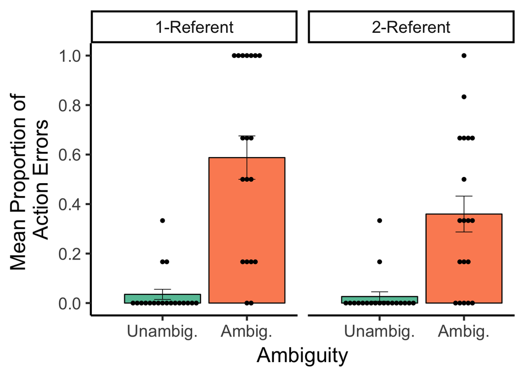

```r
levels(submean$ref) = c("1-Referent","2-Referent")
ggplot() +
  theme_classic(base_size = 20.0) +
  ylab(label = 'Mean Proportion of \nAction Errors') +
  scale_y_continuous(breaks = pretty_breaks(),limits = c(0,1)) +
  geom_bar(aes(y = errorprop, x = amb,fill = as.factor(amb)),data=submean,colour="black",fun.data = mean_sdl,stat = 'summary') +
  geom_beeswarm(aes(x = amb,y = errorprop),data=submean,dodge.width=0.9,cex=2.5) +
  geom_errorbar(aes(y = errorprop, x = amb),data=submean,size = 0.3,width = 0.2,fun.y = function(x) mean(x),fun.ymin = function(x) mean(x) - sd(x)/sqrt(length(x)),fun.ymax = function(x) mean(x) + sd(x)/sqrt(length(x)) ,stat = 'summary')+
  facet_wrap(facets = ~ref) +
  scale_x_discrete(name = 'Ambiguity',breaks = c("1","0"),labels = c("Ambig.","Unambig."))+
  scale_fill_brewer(palette = 'Set2') +
  theme(legend.position = "none")
```

- get subject-specific ambiguity effect on action

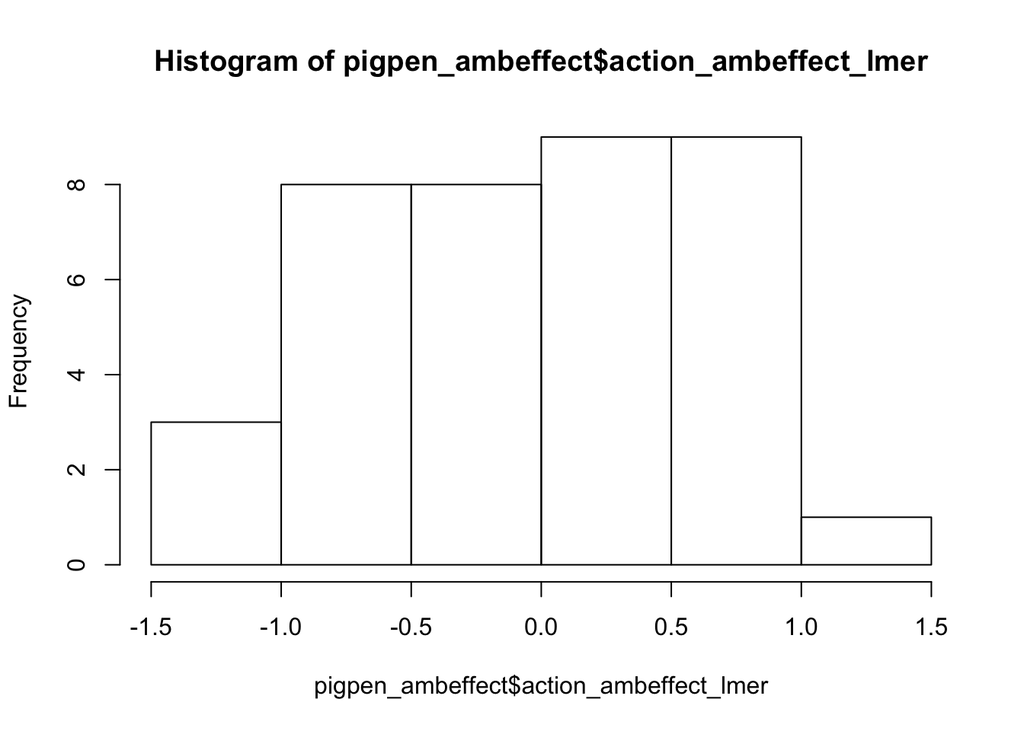

```r
pigpen_ambeffect=ranef(pigpen.lmer)$Subnum[2]
pigpen_ambeffect <- cbind(pigpen_ambeffect,pigpen_id)
colnames(pigpen_ambeffect)[1]="action_ambeffect_lmer"
colnames(pigpen_ambeffect)[2]="subnum"
hist(pigpen_ambeffect$action_ambeffect_lmer)
```

## Analysis of Fixation

- autoregreesive generalized mixed effect models of DD1 with only the experimental factors
  - no significant effect

```r
pigpen_dd1_ar1 <- read.delim("~/Dropbox (Personal)/CindyLab/EnchantedForest/Forest_Writing/pigpen_n2_onset1.txt",check.names=FALSE)
pigpen_dd1_ar1 <- subset(pigpen_dd1_ar1,Subnum %in% pigpen_id)
pigpen_dd1_ar1 <- subset(pigpen_dd1_ar1,Drop!=1)
pigpen_dd1_ar1 <- melt(pigpen_dd1_ar1,id = c(1:6))
colnames(pigpen_dd1_ar1)[7]="time"
colnames(pigpen_dd1_ar1)[8]="looks"
pigpen_dd1_ar1$ddlooks = ifelse(pigpen_dd1_ar1$looks=="DD",1,0)
pigpen_dd1_ar1 = pigpen_dd1_ar1[order(pigpen_dd1_ar1$Subnum,pigpen_dd1_ar1$Trial,pigpen_dd1_ar1$time),]
# add a column of dd looks with 1 timepoints of lag.
pigpen_dd1_ar1$ddlag1=NA
for (s in pigpen_id){
  s_trial <- unique(pigpen_dd1_ar1[pigpen_dd1_ar1$Subnum==s,]$Trial)
  for (t in s_trial){
    i = which(pigpen_dd1_ar1$Subnum==s & pigpen_dd1_ar1$Trial==t)
    for (ix in i[-1]){
      pigpen_dd1_ar1$ddlag1[ix] = pigpen_dd1_ar1$ddlooks[ix-1]
    }
  }
}
pigpen_dd1_ar1$ambcode <- ifelse(pigpen_dd1_ar1$Amb==0,-.5,.5)
pigpen_dd1_ar1$refcode<- ifelse(pigpen_dd1_ar1$Ref=="1-ref",-.5,.5)
dd1.lmer.ar1 <- glmer(ddlooks ~ 1 + ddlag1 + ambcode*refcode + (1+ddlag1+ambcode|Subnum) + (1+ddlag1+ambcode*refcode|Trial), family = binomial,control=glmerControl(optimizer="bobyqa", optCtrl=list(maxfun=2e5)),data = pigpen_dd1_ar1)
summary(dd1.lmer.ar1)
```

```
## Generalized linear mixed model fit by maximum likelihood (Laplace
##   Approximation) [glmerMod]
##  Family: binomial  ( logit )
## Formula:
## ddlooks ~ 1 + ddlag1 + ambcode * refcode + (1 + ddlag1 + ambcode |
##     Subnum) + (1 + ddlag1 + ambcode * refcode | Trial)
##    Data: pigpen_dd1_ar1
## Control:
## glmerControl(optimizer = "bobyqa", optCtrl = list(maxfun = 2e+05))
##
##      AIC      BIC   logLik deviance df.resid
##   2086.8   2287.8  -1017.4   2034.8    16814
##
## Scaled residuals:
##     Min      1Q  Median      3Q     Max
## -5.5740 -0.0905 -0.0773 -0.0660 15.8125
##
## Random effects:
##  Groups Name            Variance Std.Dev. Corr
##  Subnum (Intercept)     0.22120  0.4703
##         ddlag1          0.23587  0.4857   -1.00
##         ambcode         0.15037  0.3878    1.00 -1.00
##  Trial  (Intercept)     0.11053  0.3325
##         ddlag1          0.10477  0.3237   -0.97
##         ambcode         0.04214  0.2053   -0.48  0.24
##         refcode         0.39128  0.6255    0.24  0.02 -0.97
##         ambcode:refcode 0.27420  0.5236   -0.44  0.20  1.00 -0.98
## Number of obs: 16840, groups:  Subnum, 38; Trial, 24
##
## Fixed effects:
##                 Estimate Std. Error z value Pr(>|z|)
## (Intercept)     -5.04813    0.14972 -33.718   <2e-16 ***
## ddlag1           7.72153    0.19325  39.955   <2e-16 ***
## ambcode          0.22868    0.19226   1.189    0.234
## refcode         -0.14861    0.22168  -0.670    0.503
## ambcode:refcode  0.04226    0.36653   0.115    0.908
## ---
## Signif. codes:  0 '***' 0.001 '**' 0.01 '*' 0.05 '.' 0.1 ' ' 1
##
## Correlation of Fixed Effects:
##             (Intr) ddlag1 ambcod refcod
## ddlag1      -0.726
## ambcode      0.046 -0.120
## refcode      0.108  0.022 -0.228
## ambcod:rfcd -0.108 -0.013  0.189 -0.206
```

- autoregreesive generalized mixed effect models of DD2 with only the experimental factors
  - significant ambiguity effect

```r
pigpen_dd2_ar1 <- read.delim("~/Dropbox (Personal)/CindyLab/EnchantedForest/Forest_Writing/pigpen_n2_onset2.txt",check.names=FALSE)
pigpen_dd2_ar1 <- subset(pigpen_dd2_ar1,Subnum %in% pigpen_id)
pigpen_dd2_ar1 <- subset(pigpen_dd2_ar1,Drop!=1)
pigpen_dd2_ar1 <- melt(pigpen_dd2_ar1,id = c(1:6))
colnames(pigpen_dd2_ar1)[7]="time"
colnames(pigpen_dd2_ar1)[8]="looks"
pigpen_dd2_ar1$ddlooks = ifelse(pigpen_dd2_ar1$looks=="DD",1,0)
pigpen_dd2_ar1 = pigpen_dd2_ar1[order(pigpen_dd2_ar1$Subnum,pigpen_dd2_ar1$Trial,pigpen_dd2_ar1$time),]
# add a column of dd looks with 1 timepoints of lag.
pigpen_dd2_ar1$ddlag1=NA
for (s in pigpen_id){
  s_trial <- unique(pigpen_dd2_ar1[pigpen_dd2_ar1$Subnum==s,]$Trial)
  for (t in s_trial){
    i = which(pigpen_dd2_ar1$Subnum==s & pigpen_dd2_ar1$Trial==t)
    for (ix in i[-1]){
      pigpen_dd2_ar1$ddlag1[ix] = pigpen_dd2_ar1$ddlooks[ix-1]
    }
  }
}
pigpen_dd2_ar1$ambcode <- ifelse(pigpen_dd2_ar1$Amb==0,-.5,.5)
pigpen_dd2_ar1$refcode<- ifelse(pigpen_dd2_ar1$Ref=="1-ref",-.5,.5)
pigpen_dd2_ar1 = subset(pigpen_dd2_ar1,time!= 1500)
dd2.lmer.ar1 <- glmer(ddlooks ~ 1 + ddlag1 + ambcode*refcode + (1+ddlag1+ambcode|Subnum) + (1+ddlag1+ambcode*refcode|Trial), family = binomial,control=glmerControl(optimizer="bobyqa", optCtrl=list(maxfun=2e5)),data = pigpen_dd2_ar1)
summary(dd2.lmer.ar1)
```

```
## Generalized linear mixed model fit by maximum likelihood (Laplace
##   Approximation) [glmerMod]
##  Family: binomial  ( logit )
## Formula:
## ddlooks ~ 1 + ddlag1 + ambcode * refcode + (1 + ddlag1 + ambcode |
##     Subnum) + (1 + ddlag1 + ambcode * refcode | Trial)
##    Data: pigpen_dd2_ar1
## Control:
## glmerControl(optimizer = "bobyqa", optCtrl = list(maxfun = 2e+05))
##
##      AIC      BIC   logLik deviance df.resid
##   2055.9   2256.9  -1001.9   2003.9    16814
##
## Scaled residuals:
##     Min      1Q  Median      3Q     Max
## -4.6529 -0.0874 -0.0715 -0.0591 18.5348
##
## Random effects:
##  Groups Name            Variance Std.Dev. Corr
##  Subnum (Intercept)     0.34058  0.5836
##         ddlag1          0.26930  0.5189   -1.00
##         ambcode         0.12405  0.3522    1.00 -1.00
##  Trial  (Intercept)     0.21035  0.4586
##         ddlag1          0.13241  0.3639   -0.99
##         ambcode         0.05404  0.2325   -0.92  0.85
##         refcode         0.05931  0.2435   -0.84  0.74  0.98
##         ambcode:refcode 0.04692  0.2166    0.72 -0.60 -0.93 -0.98
## Number of obs: 16840, groups:  Subnum, 38; Trial, 24
##
## Fixed effects:
##                 Estimate Std. Error z value Pr(>|z|)
## (Intercept)     -5.19827    0.17892 -29.054  < 2e-16 ***
## ddlag1           7.31759    0.20895  35.020  < 2e-16 ***
## ambcode          0.60674    0.21127   2.872  0.00408 **
## refcode          0.03526    0.22476   0.157  0.87535
## ambcode:refcode -0.55481    0.39232  -1.414  0.15731
## ---
## Signif. codes:  0 '***' 0.001 '**' 0.01 '*' 0.05 '.' 0.1 ' ' 1
##
## Correlation of Fixed Effects:
##             (Intr) ddlag1 ambcod refcod
## ddlag1      -0.722
## ambcode     -0.134 -0.112
## refcode     -0.187 -0.080  0.308
## ambcod:rfcd  0.171  0.044 -0.332 -0.330
```

- plot the significant effect of ambiguity on the looks to distractor destination (DD2)

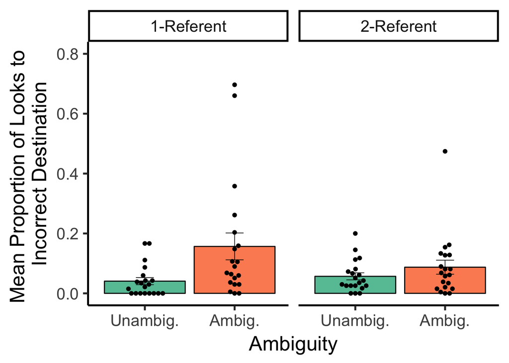

```r
eye_mean$amb=as.factor(eye_mean$amb)
levels(eye_mean$ref) =  c("1-Referent","2-Referent")
ggplot() +
  theme_classic(base_size = 20.0) +
  ylab(label = 'Mean Proportion of Looks to \nIncorrect Destination') +
  scale_y_continuous(breaks = pretty_breaks(),limits = c(0,0.8)) +
  geom_bar(aes(y = DD2, x = amb,fill = as.factor(amb)),data=eye_mean,colour="black",fun.data = mean_sdl,stat = 'summary') +
  geom_beeswarm(aes(x = amb,y = DD2),data=eye_mean,dodge.width=0.9,cex=2.5) +
  geom_errorbar(aes(y = DD2, x = amb),data=eye_mean,size = 0.3,width = 0.2,fun.y = function(x) mean(x),fun.ymin = function(x) mean(x) - sd(x)/sqrt(length(x)),fun.ymax = function(x) mean(x) + sd(x)/sqrt(length(x)) ,stat = 'summary')+
  facet_wrap(facets = ~ref) +
  scale_x_discrete(name = 'Ambiguity',breaks = c("1","0"),labels = c("Ambig.","Unambig."))+
  scale_fill_brewer(palette = 'Set2') +
  theme(legend.position = "none")
```

- get subject-specific ambiguity effect on DD2

```r
dd2_ambeffect = ranef(dd2.lmer.ar1)$Subnum[3]
dd2_ambeffect = cbind(dd2_ambeffect,pigpen_id)
dd2_se_ambeffect = se.ranef(dd2.lmer.ar1)$Subnum[,3]
dd2_ambeffect = cbind(dd2_se_ambeffect,dd2_ambeffect)
dd2_intercept = ranef(dd2.lmer.ar1)$Subnum[1]
dd2_ambeffect = cbind (dd2_intercept,dd2_ambeffect)
colnames(dd2_ambeffect)= c("intercept","dd2_se_ambeffect","dd2_ambeffect","subnum")
```

- get reliablity measure for DD2 fixation ** reliability for dd2 is 0.68

```r
dd2_ambeffect$dd2_se_sq = (dd2_ambeffect$dd2_se_ambeffect)^2
dd2_reliability = (var(dd2_ambeffect$intercept) - mean(dd2_ambeffect$dd2_se_sq))/var(dd2_ambeffect$intercept)
```

- autoregreesive generalized mixed effect models of TDinto with only the experimental factors
  - significant ambiguity effect and marginal referential context effect

```r
pigpen_td2_ar1 <- read.delim("~/Dropbox (Personal)/CindyLab/EnchantedForest/Forest_Writing/pigpen_into_onset.txt",check.names=FALSE)
pigpen_td2_ar1 <- subset(pigpen_td2_ar1,Subnum %in% pigpen_id)
pigpen_td2_ar1 <- subset(pigpen_td2_ar1,Drop!=1)
pigpen_td2_ar1 <- melt(pigpen_td2_ar1,id = c(1:6))
colnames(pigpen_td2_ar1)[7]="time"
colnames(pigpen_td2_ar1)[8]="looks"
pigpen_td2_ar1$tdlooks = ifelse(pigpen_td2_ar1$looks=="TD",1,0)
pigpen_td2_ar1 = pigpen_td2_ar1[order(pigpen_td2_ar1$Subnum,pigpen_td2_ar1$Trial,pigpen_td2_ar1$time),]
# add a column of dd looks with 1 timepoints of lag.
pigpen_td2_ar1$tdlag1=NA
for (s in pigpen_id){
  s_trial <- unique(pigpen_td2_ar1[pigpen_td2_ar1$Subnum==s,]$Trial)
  for (t in s_trial){
    i = which(pigpen_td2_ar1$Subnum==s & pigpen_td2_ar1$Trial==t)
    for (ix in i[-1]){
      pigpen_td2_ar1$tdlag1[ix] = pigpen_td2_ar1$tdlooks[ix-1]
    }
  }
}
pigpen_td2_ar1$ambcode <- ifelse(pigpen_td2_ar1$Amb==0,-.5,.5)
pigpen_td2_ar1$refcode<- ifelse(pigpen_td2_ar1$Ref=="1-ref",-.5,.5)
td2.lmer.ar1 <- glmer(tdlooks ~ 1 + tdlag1 + ambcode*refcode + (1+tdlag1+ambcode|Subnum) + (1+tdlag1+ambcode+refcode|Trial), family = binomial,control=glmerControl(optimizer="bobyqa", optCtrl=list(maxfun=2e5)),data = pigpen_td2_ar1)
summary(td2.lmer.ar1)
```

```
## Generalized linear mixed model fit by maximum likelihood (Laplace
##   Approximation) [glmerMod]
##  Family: binomial  ( logit )
## Formula:
## tdlooks ~ 1 + tdlag1 + ambcode * refcode + (1 + tdlag1 + ambcode |
##     Subnum) + (1 + tdlag1 + ambcode + refcode | Trial)
##    Data: pigpen_td2_ar1
## Control:
## glmerControl(optimizer = "bobyqa", optCtrl = list(maxfun = 2e+05))
##
##      AIC      BIC   logLik deviance df.resid
##   3285.5   3450.8  -1621.7   3243.5    19345
##
## Scaled residuals:
##     Min      1Q  Median      3Q     Max
## -6.9670 -0.1114 -0.0995 -0.0865 12.5241
##
## Random effects:
##  Groups Name        Variance Std.Dev. Corr
##  Subnum (Intercept) 0.097827 0.31277
##         tdlag1      0.012131 0.11014  -0.74
##         ambcode     0.080554 0.28382  -0.87  0.31
##  Trial  (Intercept) 0.066258 0.25741
##         tdlag1      0.008421 0.09176  -1.00
##         ambcode     0.001364 0.03694  -1.00  1.00
##         refcode     0.008835 0.09399  -1.00  1.00  1.00
## Number of obs: 19366, groups:  Subnum, 38; Trial, 24
##
## Fixed effects:
##                 Estimate Std. Error z value Pr(>|z|)
## (Intercept)      -4.4789     0.1075 -41.649   <2e-16 ***
## tdlag1            7.3617     0.1227  59.975   <2e-16 ***
## ambcode          -0.2962     0.1307  -2.266   0.0234 *
## refcode           0.2633     0.1494   1.763   0.0779 .
## ambcode:refcode  -0.2720     0.2452  -1.109   0.2673
## ---
## Signif. codes:  0 '***' 0.001 '**' 0.01 '*' 0.05 '.' 0.1 ' ' 1
##
## Correlation of Fixed Effects:
##             (Intr) tdlag1 ambcod refcod
## tdlag1      -0.583
## ambcode     -0.122  0.032
## refcode     -0.100  0.031  0.007
## ambcod:rfcd  0.024 -0.042 -0.065 -0.150
```

- plot the significant effect of ambiguity on the looks to correct destination (TD2)

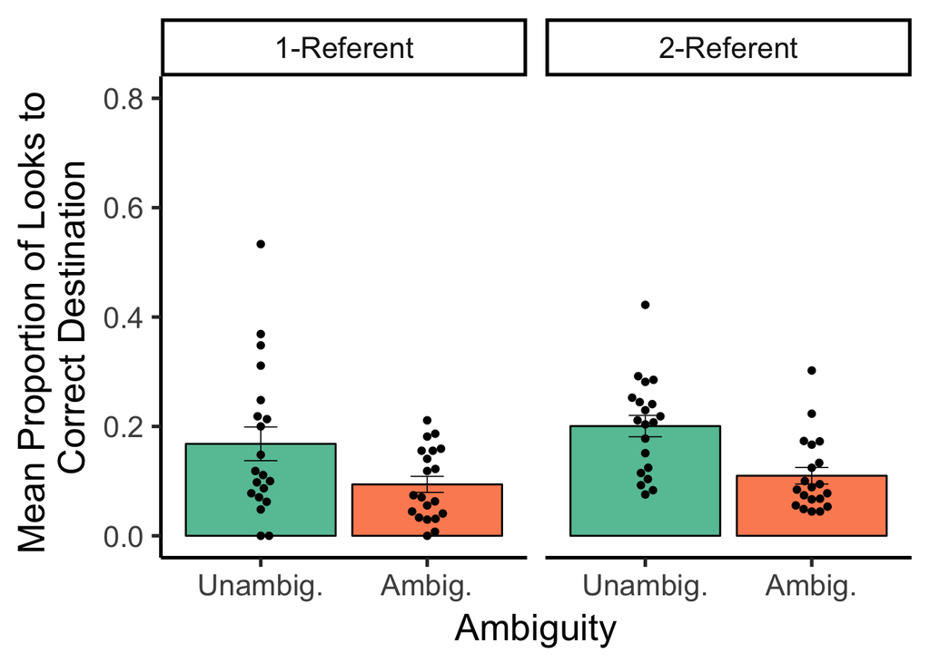

```r
ggplot() +
  theme_classic(base_size = 20.0) +
  ylab(label = 'Mean Proportion of Looks to \nCorrect Destination') +
  scale_y_continuous(breaks = pretty_breaks(),limits = c(0,0.8)) +
  geom_bar(aes(y = Tdinto, x = amb,fill = as.factor(amb)),data=eye_mean,colour="black",fun.data = mean_sdl,stat = 'summary') +
  geom_beeswarm(aes(x = amb,y = Tdinto),data=eye_mean,dodge.width=0.9,cex=2.5) +
  geom_errorbar(aes(y = Tdinto, x = amb),data=eye_mean,size = 0.3,width = 0.2,fun.y = function(x) mean(x),fun.ymin = function(x) mean(x) - sd(x)/sqrt(length(x)),fun.ymax = function(x) mean(x) + sd(x)/sqrt(length(x)) ,stat = 'summary')+
  facet_wrap(facets = ~ref) +
  scale_x_discrete(name = 'Ambiguity',breaks = c("1","0"),labels = c("Ambig.","Unambig."))+
  scale_fill_brewer(palette = 'Set2') +
  theme(legend.position = "none")
```

- get subject-specific ambiguity effect on TD2

```r
td2_ambeffect = ranef(td2.lmer.ar1)$Subnum[3]
td2_ambeffect = cbind(td2_ambeffect,pigpen_id)
td2_se_ambeffect = se.ranef(td2.lmer.ar1)$Subnum[,3]
td2_ambeffect = cbind(td2_se_ambeffect,td2_ambeffect)
td2_intercept = ranef(td2.lmer.ar1)$Subnum[1]
td2_ambeffect = cbind (td2_intercept,td2_ambeffect)
colnames(td2_ambeffect)= c("intercept","td2_se_ambeffect","td2_ambeffect","subnum")
```

- get reliablity measure for TD2 fixation ** reliability for td2 is -0.10

```r
td2_ambeffect$td2_se_sq = (td2_ambeffect$td2_se_ambeffect)^2
td2_reliability = (var(td2_ambeffect$intercept) - mean(td2_ambeffect$td2_se_sq))/var(td2_ambeffect$intercept)
td2_reliability
```

```
## [1] -0.1086872
```

## individual difference analysis

- compute switch cost of flanker task

```
## [1] 0.8032653
```

```
##
##  Paired t-test
##
## data:  switch_acc$sw_acc and switch_acc$nonsw_acc
## t = 1.434, df = 37, p-value = 0.16
## alternative hypothesis: true difference in means is not equal to 0
## 95 percent confidence interval:
##  -0.01492043  0.08718727
## sample estimates:
## mean of the differences
##              0.03613342
```

```
## [1] 233.1651
```

```
##
##  Paired t-test
##
## data:  switch_rt$sw_rt and switch_rt$nonsw_rt
## t = 5.1521, df = 37, p-value = 8.809e-06
## alternative hypothesis: true difference in means is not equal to 0
## 95 percent confidence interval:
##  141.4670 324.8633
## sample estimates:
## mean of the differences
##                233.1651
```

- testing the pearson correlation between ambeffect and individual difference measures
  - significant correlation between Flanker accuracy in the incongruent condition and Action ambiguity effect, as well as incorrect and correct destination looks (replicating Forest); the relationship between raw PPVT score and the ambiguity effect on the looks to incorrect destination is in the oppsite direction from (Anderson et al., 2011). Children with higher PPVT score seem to have higher switch cost in Flanker test…
- list correlation pearson r values

```
##                      Age FlankerIncong        PPVT FlankerSwitch
## Age           1.00000000    0.12187099  0.25318143    0.09763573
## FlankerIncong 0.12187099    1.00000000 -0.02928737   -0.09522446
## PPVT          0.25318143   -0.02928737  1.00000000    0.28004761
## FlankerSwitch 0.09763573   -0.09522446  0.28004761    1.00000000
## Action        0.06426404   -0.36807414  0.13537743    0.13860680
## DD2           0.07154270   -0.31320679  0.32957630    0.35925429
## TD2           0.14351297    0.34403491 -0.08371042   -0.07550566
##                    Action        DD2         TD2
## Age            0.06426404  0.0715427  0.14351297
## FlankerIncong -0.36807414 -0.3132068  0.34403491
## PPVT           0.13537743  0.3295763 -0.08371042
## FlankerSwitch  0.13860680  0.3592543 -0.07550566
## Action         1.00000000  0.6454319 -0.20602397
## DD2            0.64543194  1.0000000 -0.26112367
## TD2           -0.20602397 -0.2611237  1.00000000
```

- list correlation p values (one-sided)

```
##                      Age FlankerIncong       PPVT FlankerSwitch
## Age           0.50000000    0.23303420 0.06255302    0.27989356
## FlankerIncong 0.23303420    0.50000000 0.43071826    0.28478363
## PPVT          0.06255302    0.43071826 0.50000000    0.04429104
## FlankerSwitch 0.27989356    0.28478363 0.04429104    0.50000000
## Action        0.35074371    0.01149371 0.20885920    0.20329647
## DD2           0.33475003    0.02776364 0.02165931    0.01337482
## TD2           0.19500950    0.01721631 0.30865502    0.32615914
##                     Action          DD2        TD2
## Age           3.507437e-01 3.347500e-01 0.19500950
## FlankerIncong 1.149371e-02 2.776364e-02 0.01721631
## PPVT          2.088592e-01 2.165931e-02 0.30865502
## FlankerSwitch 2.032965e-01 1.337482e-02 0.32615914
## Action        5.000000e-01 6.063443e-06 0.10731086
## DD2           6.063443e-06 5.000000e-01 0.05665195
## TD2           1.073109e-01 5.665195e-02 0.50000000
```

- because flanker switch cost is significantly correlated with PPVT, we performed a multiple linear regression model for each of the DVs.
  - flanker accuracy in the incongruent condition contributes uniquely to offline ambiguity resolution;

```r
m1.0 <- lm(action_ambeffect_lmer~Age+PropInc3+sw_rtdiff+raw,data=pigpen_indiv)
summary(m1.0)
```

```
##
## Call:
## lm(formula = action_ambeffect_lmer ~ Age + PropInc3 + sw_rtdiff +
##     raw, data = pigpen_indiv)
##
## Residuals:
##      Min       1Q   Median       3Q      Max
## -1.14781 -0.44410  0.06553  0.39618  1.22116
##
## Coefficients:
##               Estimate Std. Error t value Pr(>|t|)
## (Intercept) -0.8078282  2.3771790  -0.340   0.7361
## Age          0.0199753  0.0410684   0.486   0.6299
## PropInc3    -1.2454551  0.5459545  -2.281   0.0291 *
## sw_rtdiff    0.0001659  0.0003839   0.432   0.6683
## raw          0.0032268  0.0065733   0.491   0.6268
## ---
## Signif. codes:  0 '***' 0.001 '**' 0.01 '*' 0.05 '.' 0.1 ' ' 1
##
## Residual standard error: 0.6222 on 33 degrees of freedom
## Multiple R-squared:  0.1622, Adjusted R-squared:  0.06068
## F-statistic: 1.598 on 4 and 33 DF,  p-value: 0.1982
```

```
+ neither vocabulary nor flanker switch cost alone contribute significantly to online ambiguity resolution
```

```r
m2.0 <- lm(dd2_ambeffect~Age+PropInc3+sw_rtdiff+raw,data=pigpen_indiv)
summary(m2.0)
```

```
##
## Call:
## lm(formula = dd2_ambeffect ~ Age + PropInc3 + sw_rtdiff + raw,
##     data = pigpen_indiv)
##
## Residuals:
##      Min       1Q   Median       3Q      Max
## -0.30596 -0.13797 -0.04890  0.09939  0.65570
##
## Coefficients:
##               Estimate Std. Error t value Pr(>|t|)
## (Intercept) -0.3019048  0.8934832  -0.338   0.7376
## Age          0.0018760  0.0154359   0.122   0.9040
## PropInc3    -0.3841225  0.2052017  -1.872   0.0701 .
## sw_rtdiff    0.0002422  0.0001443   1.679   0.1027
## raw          0.0037488  0.0024706   1.517   0.1387
## ---
## Signif. codes:  0 '***' 0.001 '**' 0.01 '*' 0.05 '.' 0.1 ' ' 1
##
## Residual standard error: 0.2339 on 33 degrees of freedom
## Multiple R-squared:  0.2645, Adjusted R-squared:  0.1753
## F-statistic: 2.966 on 4 and 33 DF,  p-value: 0.03376
```

- Scatter plots of individual difference measures and the sentence task
  - plot the correlation between Flanker Accuracy in the Incongruent condition and the Ambiguity effect on action

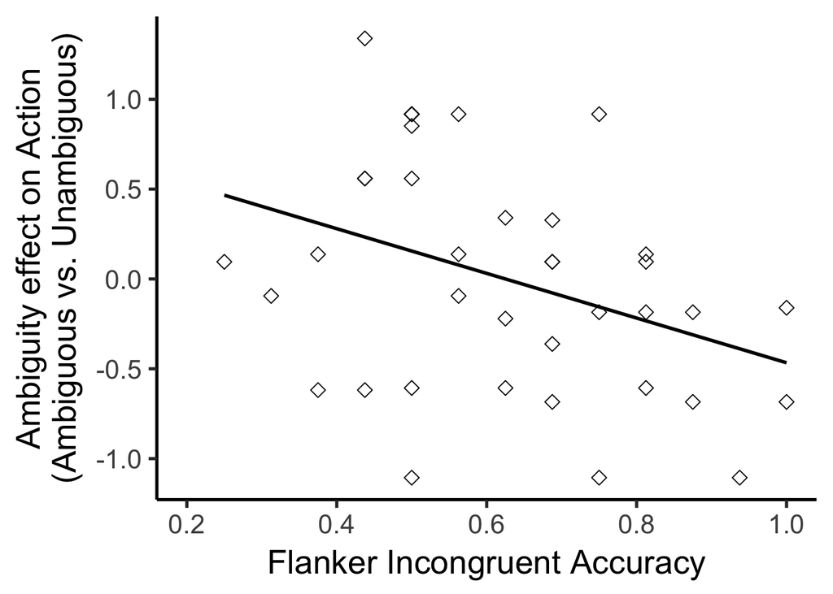

  - plot the correlation between Flanker Accuracy in the Incongruent condition and the Ambiguity effect on distractor destination looks

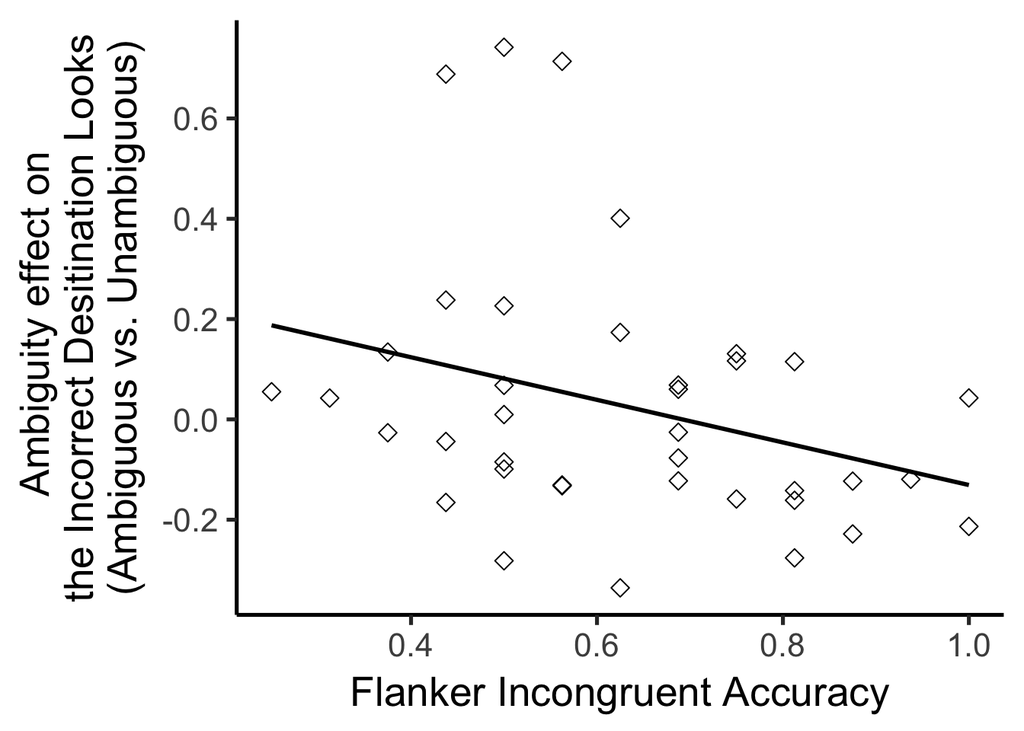

  - plot the correlation between Flanker switch cost and the Ambiguity effect on distractor destination looks

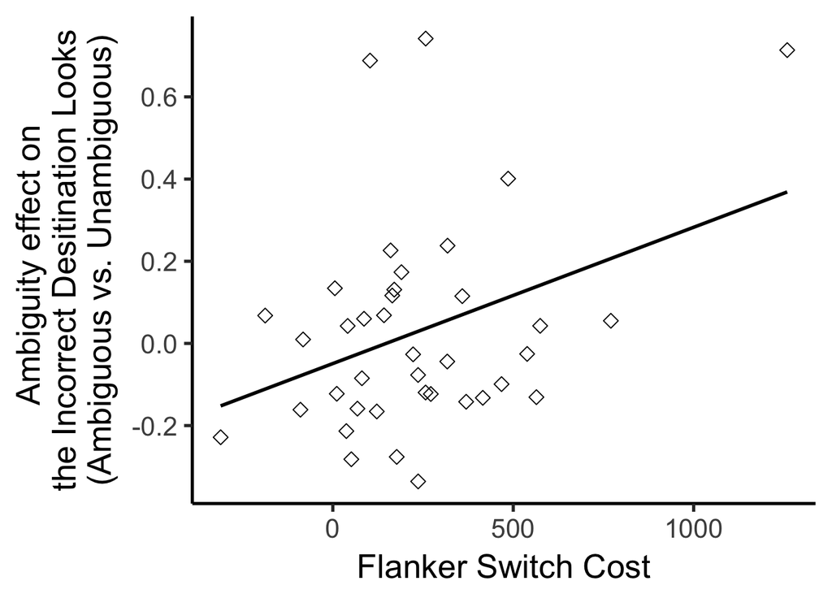